# Covid19 Spread Exploration MiniTool

4/14/2020

## Covid19 spread rate apliccation

This is an Introduction (Executive Summary) to my final project in **Developing Data Products** course.

We all experience strange time these days while the Covid19 epidemic continue to hit and kill Thousands of victims every day.

The Data Sience world harrnesses all the knowledge and practical tools it has to help in the shared effort of fighting the virus.

With **Covid19 spreading rate comparison application** we hope to make our modest contribution to that effort by enabling a clear and easy way to compare the virus spreading rate between countries all over the world.

## What it does:

The application presents a graph of confirmed cases within the selected countries (one or many) for certain date range, define by the user.

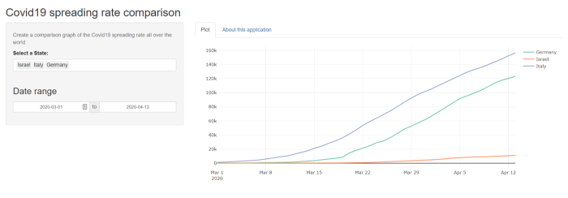

The home page of the application

## The Data Source(part 1):

The dataset Behind the Scenes comes from “Our World In Data” [Website](https://ourworldindata.org/coronavirus-source-data).

The original data format is a bit messy and there are some cleaning and redesigning work needed to be done.

Here is the original:

```
##         date World Afghanistan Albania Algeria Andorra Angola Anguilla
## 1 2019-12-31    27           0      NA       0      NA     NA       NA
## 2 2020-01-01    27           0      NA       0      NA     NA       NA
## 3 2020-01-02    27           0      NA       0      NA     NA       NA
## 4 2020-01-03    44           0      NA       0      NA     NA       NA
## 5 2020-01-04    44           0      NA       0      NA     NA       NA
##   Antigua.and.Barbuda Argentina Armenia Aruba Australia Austria Azerbaijan
## 1                  NA        NA       0    NA         0       0          0
## 2                  NA        NA       0    NA         0       0          0
## 3                  NA        NA       0    NA         0       0          0
## 4                  NA        NA       0    NA         0       0          0
## 5                  NA        NA       0    NA         0       0          0
##   Bahamas Bahrain Bangladesh Barbados Belarus Belgium Belize Benin Bermuda
## 1      NA       0         NA       NA       0       0     NA    NA      NA
## 2      NA       0         NA       NA       0       0     NA    NA      NA
```

[output cut: 159 more lines]

## The Data Source (part 2):

As we can see in this dataset, the variables(columns) are the countries and the date while the observations(rows) are the sum of cases per day.

In order to enable more conviniet structure we had to transform the shape of the dataset:

```
##         date Country Cases
## 1 2019-12-31   World    27
## 2 2020-01-01   World    27
## 3 2020-01-02   World    27
## 4 2020-01-03   World    44
## 5 2020-01-04   World    44
## 6 2020-01-05   World    59
```

This format make it easy for the application to plot the comparison graph.